# UW Athletics Data Contest

## Data Cleaning

The way I did the scraping, we are now left with 11 different directories, each with a `.csv` file, and a `.R` script file that scrapes the data, and generates those `.csv` files.

### Reading and Combining

The approach I took is to get those `.csv.` files recursively from the home directory that houses all of these subdirectories.

```r
# Get all files from this directory
files = list.files(recursive=T)

# Get all .csv files, this will remove the .R scripts
csv_files = files[endsWith(files, ".csv")]
csv_files = csv_files[!(csv_files %in% c("geocodes.csv", "rosters.csv"))]


all_schools = data.frame()

# Combine all of the content from each csv together into one large dataframe.
for (f in csv_files) {
  file = read_csv(f)
  file$School = rep(str_split_1(f, "/")[1], nrow(file))
  all_schools = rbind(all_schools, file)
}
```

We can see the head and tail of this dataset, showing we have combined all the data for all schools.

```r
show_table(head(all_schools))
```

| Name | Hometown | Year | Sport | School |
| --- | --- | --- | --- | --- |
| Mikey White | Birmingham, Ala. | 2014 | baseball | Alabama |
| Daniel Cucjen | Shreveport, La. | 2014 | baseball | Alabama |
| Kyle Overstreet | Boaz, Ala. | 2014 | baseball | Alabama |
| Ben Moore | Cullman, Ala. | 2014 | baseball | Alabama |
| Casey Hughston | Mobile, Ala. | 2014 | baseball | Alabama |
| Wade Wass | Pensacola, Fla. | 2014 | baseball | Alabama |

```r
show_table(tail(all_schools))
```

| Name | Hometown | Year | Sport | School |
| --- | --- | --- | --- | --- |
| Molly Finlay | Oakton, Va. | 2023 | wlax | Vanderbilt |
| Ashley Sampone | Rochester, N.Y. | 2023 | wlax | Vanderbilt |
| Taylor Sampone | Rochester, N.Y. | 2023 | wlax | Vanderbilt |
| Kristin Gruber | Woodbine, Md. | 2023 | wlax | Vanderbilt |
| Molly Krestinski | Bronxville, N.Y. | 2023 | wlax | Vanderbilt |
| Remy Ricciardi | Ridgewood, N.J. | 2023 | wlax | Vanderbilt |

When scraping and creating these `.csv` files, I just added the sport names as the universities had structured them, so some of them had different names. We need to loop through the sport vector and create some sort of standard naming for the sport names, so that they can be visualized. Here we can see all the different names we have of sports.

```r
sport_names = all_schools$Sport
unique(sport_names)
```

```
##  [1] "baseball"                   "softball"
##  [3] "mens-basketball"            "womens-basketball"
##  [5] "football"                   "mens-golf"
##  [7] "womens-golf"                "swimming-and-diving"
##  [9] "womens-gymnastics"          "womens-soccer"
## [11] "xctrack"                    "womens-tennis"
## [13] "mens-tennis"                "womens-volleyball"
## [15] "womens-rowing"              "m-basebl"
## [17] "w-softbl"                   "m-baskbl"
## [19] "w-baskbl"                   "m-footbl"
## [21] "m-golf"                     "w-golf"
## [23] "w-swim"                     "w-gym"
## [25] "w-soccer"                   "m-track"
## [27] "w-track"                    "m-xc"
## [29] "w-xc"                       "w-tennis"
```

[output cut: 21 more lines]

I don’t want to do this automatically with a loop (and with things like regular expressions) so I’m going to just create a manual dataframe by combining two lists together.

```r
names = unique(sport_names)
name_replacements = c("baseball", "softball", "mens-basketball", "womens-basketball", "football", "mens-golf", "womens-golf", "swimming-and-diving", "gymnastics", "womens-soccer", "xc-track", "womens-tennis", "mens-tennis", "volleyball", "womens-rowing", "baseball", "softball", "mens-basketball", "womens-basketball", "football", "mens-golf", "womens-golf", "swimming-and-diving", "gymnastics", "womens-soccer", "xc-track", "xc-track", "xc-track", "xc-track", "womens-tennis", "mens-tennis", "volleyball", "xc-track", "swimming-and-diving", "swimming-and-diving", "xc-track", "womens-lacrosse", "mens-basketball", "womens-basketball", "xc-track", "mens-golf", "womens-golf", "swimming-and-diving", "gymnastics", "mens-soccer", "womens-soccer", "xc-track", "mens-tennis", "womens-tennis", "volleyball", "baseball", "softball", "mens-basketball", "xc-track", "football", "mens-golf", "womens-golf", "swimming-and-diving", "gymnastics", "womens-soccer", "xc-track", "mens-tennis", "womens-tennis", "volleyball", "beach-volleyball", "wrestling", "xc-track", "xc-track", "swimming-and-diving", "xc-track", "womens-lacrosse")

sport_name_changes = data.frame(Name = names, Modified = name_replacements)
show_table(tail(sport_name_changes))
```

|  | Name | Modified |
| --- | --- | --- |
| 66 | wrestling | wrestling |
| 67 | wcross | xc-track |
| 68 | mcross | xc-track |
| 69 | wswim | swimming-and-diving |
| 70 | wtrack | xc-track |
| 71 | wlax | womens-lacrosse |

This adjustment also allows me to combine some men’s/women’s sports together. Some universities combine the rosters, while some don’t, so this allows me to combine sports like cross country, track and field, and swimming and diving.

```r
# Apply this to the all_sports sport list

new_sports = c()

for (sport in all_schools$Sport){
  new_sports = c(new_sports, sport_name_changes[sport_name_changes["Name"] == sport][2])
}
all_schools$Sport = new_sports



print(paste("Old number of names:", length(names), "New number of names", length(unique(new_sports))))
```

```
## [1] "Old number of names: 71 New number of names 19"
```

### Standardizing State Names

All of the city names are not the same, that is just the nature of scraping from these different websites. So we have to try and standardize as best as possible in order to produce relevant data.

```r
hometowns = data.frame(City = all_schools$Hometown)

states = c()
cities = c()
for (city in hometowns$City){
  if (is.na(city)){
    states = c(states, NA)
    cities = c(cities, NA)
    next
  }
  cities = c(cities, str_trim(str_split_1(city, ",")[1]))
  states = c(states, str_trim(str_split_1(city, ",")[2]))
}

hometowns$Town = cities
hometowns$State = states
```

Behind the scenes, I used a script to help standardize the states, so that we don’t have multiple instances of the same city. Now we can combine this back to the original format.

```r
hometowns$City = paste(hometowns$Town, ", ", hometowns$State, sep="")
all_schools$Hometown = hometowns$City

# Write this to a csv to use for geocoding script
write.csv(all_schools, "rosters.csv", row.names=F)
```

### Geocoding the Data

I created a `geocodes.R` script that takes the cities in the players dataset and geocodes all 5000+ unique cities. This way we can map them and show all the different areas these student-athletes come from. Here is what that script looks like.

```r
library(tidyverse)
library(ggmap)

# Get the rosters.csv file we just wrote
players = read_csv("rosters.csv")

# Read the API key from our .REnviron file
readRenviron("./.Renviron")
register_google(Sys.getenv("MAPSAPIKEY"))


cities = data.frame(unique(players$Hometown))
cities$Hometown = cities$unique.players.Hometown.
cities = cities %>% select(Hometown) %>% drop_na()


# Geocode all of the cities
geocoded_cities = mutate_geocode(cities, Hometown)

write_csv(distinct(geocoded_cities %>% select(Hometown, lon, lat)), "./geocodes.csv")
```

Here is part of what that returns.

```r
geocodes = read_csv("geocodes.csv")
show_table(head(geocodes))
```

| Hometown | lon | lat |
| --- | --- | --- |
| Birmingham, Alabama | -86.81036 | 33.51859 |
| Shreveport, Louisiana | -93.75018 | 32.52515 |
| Boaz, Alabama | -86.15210 | 34.20317 |
| Cullman, Alabama | -86.84361 | 34.17482 |
| Mobile, Alabama | -88.03989 | 30.69537 |
| Pensacola, Florida | -87.21691 | 30.42131 |

To help with the map, I will add a metric that has the top school of choice for each hometown.

```r
schools = all_schools %>% select(Hometown, School) %>% group_by(Hometown, School) %>% summarize(n = length(Hometown)) %>% drop_na()

# SQL query to find the School with the most players from that city.
cities = sqldf("SELECT Hometown, School, max(n) as Num_Players FROM schools GROUP BY Hometown")

# Add all of these schools and their respective number of players to the geocodes dataframe
top_schools = c()
ns = c()
for (city in geocodes$Hometown) {
  df = cities[cities["Hometown"] == city,] %>% select(School, Num_Players)
  top_schools = append(top_schools, df$School[1])
  ns = append(ns, df$Num_Players[1])
}

geocodes$School = top_schools
geocodes$Num_Players = ns
```

### Mapping the Data

We will use the leaflet package for this portion. This will give us a nice interactive map we can look at.

```r
# These are some mapping functions that will allow us to see not only some statistics on the cities, but color them so we know what schools are getting the most recruits from each city.

school_color = function (school) {

  school = school[1]

  if (is.na(school)){
    return ("black")
  }

  if (school == "Alabama") {
    return ("#9E1B32")
  }

  if (school == "Auburn"){
    return ("#E87722")
  }

  if (school == "Missouri"){
    return ("#F1B82D")
  }

  if (school == "Arkansas"){
    return ("#9D2235")
  }

  if (school == "Kentucky") {
    return ("#0033A0")
  }

  if (school == "Florida") {
    return ("#0021A5")
  }
  if (school == "Mississippi State") {
    return ("#5D1725")
  }
  if (school == "LSU") {
    return ("#461D7C")
  }
  if (school == "South Carolina") {
    return ("#73000A")
  }
  if (school == "Vanderbilt") {
    return ("#866D4B")
  }


}

colors = c()
for (school in geocodes$School){
  colors = c(colors, school_color(school))
}
geocodes$Color = colors

# Colors group for future plotting

group.colors = c("Alabama" = "#9E1B32", "Arkansas" = "#9D2235", "Auburn" = "#E87722", "Florida" = "#0021A5", "Kentucky" = "#0033A0", "LSU" = "#461D7C", "Mississippi State" = "#5D1725", "Missouri" = "#F1B82D", "South Carolina" = "#73000A", "Vanderbilt" = "#866D4B")
```

```r
m = leaflet() %>%
  addProviderTiles(provider=providers$Esri.WorldGrayCanvas) %>%
  addCircleMarkers(geocodes$lon, geocodes$lat, label=geocodes$Hometown, popup=paste("<b>", geocodes$Hometown, "</b><br>", geocodes$Num_Players, "were recruited to", geocodes$School), radius=4.5, color=geocodes$Color, fillOpacity=1.0, stroke=F)
m
```

[interactive chart not shown]

### Adding Census Data

First, we retrieve the data from the census API, and clean it up slightly.

```r
readRenviron("./.Renviron")
api_key = Sys.getenv("CENSUSKEY")

# Create our url string
url = str_glue("https://api.census.gov/data/2019/acs/acs5?get=NAME,B01002_001E,B02001_002E,B02001_003E,B25010_001E,B01003_001E&for=place:*&in=state:*&key={api_key}")

data = fromJSON(url)

census_data = data.frame(data) %>% slice(2:nrow(data))
colnames(census_data) = c("City", "Avg_Age", "B02001_002E", "B02001_003E", "Avg_Household_Size", "Total_Pop", "state", "place")

# Change column names
census_data$B02001_002E = as.numeric(census_data$B02001_002E)
census_data$B02001_003E = as.numeric(census_data$B02001_003E)
census_data$Total_Pop = as.numeric(census_data$Total_Pop)

# Calculate percentages
census_data = census_data %>%
  mutate(Percent_White = (B02001_002E/Total_Pop) * 100) %>%
  mutate(Percent_Black = (B02001_003E/Total_Pop) * 100) %>%
  select(City, Avg_Age, Percent_White, Percent_Black, Avg_Household_Size)
```

```r
# Split City and State
split_city = function(name){
  split_list = strsplit(name, ",")[[1]]

  city_name = split_list[1]

  city_split = strsplit(city_name, " ")[[1]]
  city_name = paste(city_split[-length(city_split)], collapse = " ")

  return (city_name)
}

get_state = function(name) {
  split_list = strsplit(name, ",")[[1]]

  state = str_trim(split_list[2])

  return(state)
}
```

```r
# Apply City and State Calculations to Census data
census_data$State = lapply(census_data$City, get_state)
census_data$City = lapply(census_data$City, split_city)
census_data$City_str = paste(census_data$City, ", ", census_data$State, sep="")
```

## Data Visualizations

Below are some different visualizations that I think can represent some of this data in a effective manner.

### Census Data

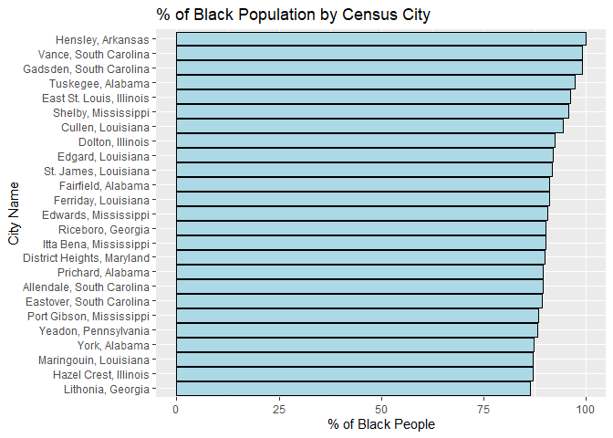

```r
cities_w_census = census_data %>%
  filter(City_str %in% cities$Hometown)


# What cities in our database have the highest percentage of black players?

pct_black = cities_w_census %>%
  select(City_str, Percent_Black) %>%
  arrange(desc(Percent_Black)) %>%
  top_n(25)

ggplot(pct_black, aes(y=reorder(City_str, Percent_Black), x=Percent_Black)) +
  geom_col(fill="lightblue", color="black") +
  ylab("City Name") +
  xlab("% of Black People") +
  ggtitle("% of Black Population by Census City")
```

Let’s plot the top 50 towns now, and see where they land on the map in accordance with the players.

```r
register_google(Sys.getenv("MAPSAPIKEY"))

geocoded_top_50 = cities_w_census %>%
  select(City_str, Percent_Black) %>%
  arrange(desc(Percent_Black)) %>%
  top_n(50) %>%
  mutate_geocode(City_str)

m %>% addCircleMarkers(geocoded_top_50$lon, geocoded_top_50$lat, label=geocoded_top_50$City_str, popup=paste("<b>", geocoded_top_50$City_str, "</b><br>", round(geocoded_top_50$Percent_Black, 2), "% Black"), color="purple")
```

[interactive chart not shown]

Let’s use the cities dataframe to find the top schools for each of these census cities, so we can see more effectively where players from these places are attending.

```r
# Get top schools for each census city
tempdf1 = cities %>% filter(Hometown %in% cities_w_census$City_str)

census_top_schools = c()

for (i in 1:nrow(cities_w_census)){
  city = tempdf1[tempdf1["Hometown"] == cities_w_census$City_str[i],]
  census_top_schools = c(census_top_schools, city$School)
}

cities_w_census$Top_School = census_top_schools
```

Which schools are high-black/white recruits attending?

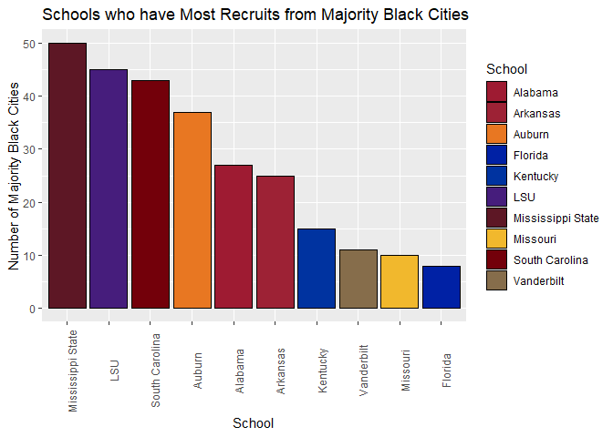

```r
cities_w_census %>%
  filter(Percent_Black > 50) %>%
  count(Top_School) %>%
  arrange(desc(n)) %>%
  ggplot(aes(x=reorder(Top_School, -n), y=n, fill=Top_School)) +
  geom_col(color = "black") +
  scale_fill_manual(values=group.colors) +
  theme(axis.text.x = element_text(angle=90, vjust=1)) +
  xlab("School") +
  ylab("Number of Majority Black Cities") +
  ggtitle("Schools who have Most Recruits from Majority Black Cities") +
  guides(fill=guide_legend(title="School"))
```

Naturally, we would expect to see opposite results from majority white cities.

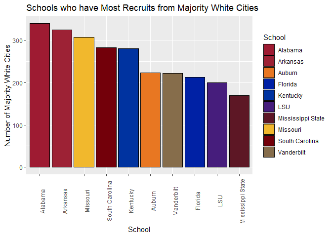

```r
cities_w_census %>%
  filter(Percent_White > 50) %>%
  count(Top_School) %>%
  arrange(desc(n)) %>%
  ggplot(aes(x=reorder(Top_School, -n), y=n, fill=Top_School)) +
  geom_col(color = "black") +
  scale_fill_manual(values=group.colors) +
  theme(axis.text.x = element_text(angle=90, vjust=1)) +
  xlab("School") +
  ylab("Number of Majority White Cities") +
  ggtitle("Schools who have Most Recruits from Majority White Cities") +
  guides(fill=guide_legend(title="School"))
```

We see that many of the schools who previously brought more black student-athletes in, tend to be less likely to be a top school in a majority white city.

Let’s also take into account how many majority white cities there are in comparison with majority black cities. While this is to be expected due to African-Americans being a large minority, it is important to visualize.

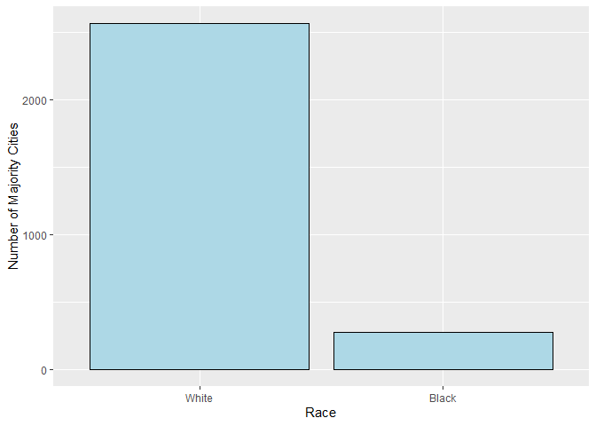

```r
num_black_cities = nrow(cities_w_census %>% filter(Percent_Black > 50))
num_white_cities = nrow(cities_w_census %>% filter(Percent_White > 50))

num_cities_df = data.frame(Race = c("Black", "White"), Num_Majority_Cities = c(num_black_cities, num_white_cities))

ggplot(num_cities_df, aes(x=reorder(Race, -Num_Majority_Cities), y=Num_Majority_Cities)) +
  geom_col(fill="lightblue", color="black") +
  ylab("Number of Majority Cities") +
  xlab("Race")
```

### Distance Away From Home

I am quite fascinated by the world of Name, Image, and Likeness (NIL), as well as the impact of the transfer portal on the world of college sports. It started on July 1, 2021, so let’s take into account some things with its impact.

First, lets do some data cleaning/calculations to determine spherical distances from each city to its respective school.

```r
universities = unique(schools$School)
uni_cities = c("Nashville, TN", "Lexington, KY", "Tuscaloosa, AL", "Gainesville, FL", "Baton Rouge, LA", "Starkville, MS", "Columbia, SC", "Fayetteville, AR", "Auburn, AL", "Columbia, MO")

# Add each university's city so it can be geocoded for distance calculations
school_locs = data.frame(School = universities, City = uni_cities) %>% mutate_geocode(City)
```

In the next two chunks, I add each city’s geocoded location to the `all_schools` dataframe, as well as the geocoded location for each school in the dataframe.

```r
lons = c()
lats = c()

# Apply to all players dataframe
for (city in all_schools$Hometown) {
  geocode = geocodes[geocodes$Hometown == city,]
  lons = c(lons, geocode$lon)
  lats = c(lats, geocode$lat)
}

all_schools$lon = lons
all_schools$lat = lats
```

```r
sc_lons = c()
sc_lats = c()
for (school in all_schools$School) {
  code = school_locs[school_locs$School == school,]
  sc_lons = c(sc_lons, code$lon)
  sc_lats = c(sc_lats, code$lat)
}

all_schools$school_lon = sc_lons
all_schools$school_lat = sc_lats
```

Now with those geocodes in place, we can calculate the Haversine distance (distance across a sphere) of each city-school pair.

```r
dists = c()

for (i in 1:nrow(all_schools)) {
  # Calculate distance, divide by 1000 for km
  dists = c(dists, distHaversine(c(all_schools$lon[i], all_schools$lat[i]), c(all_schools$school_lon[i], all_schools$school_lat[i]))/1000)
}

all_schools$school_dist = dists
```

Now we can group this by school, and by year, and find the variance.

```r
schools_dist_var = all_schools %>%
  drop_na() %>%
  group_by(School, Year) %>%
  summarize(distance_var = var(school_dist)) %>%
  mutate(Color = school_color(School), label= toupper(substr(School, 1, 3)))
```

Now we can take each schools variance in distance over time, and see how “spread out” their recruitment is.

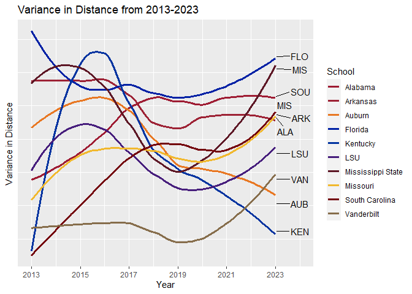

```r
# This allows for nice labels
ends = schools_dist_var %>% filter(Year == 2023)

ggplot(schools_dist_var, aes(x=Year, y=distance_var)) +
  geom_smooth(aes(color=School), ,se=F, size=1.25) +
  scale_color_manual(values=group.colors) +
  scale_x_continuous(breaks=c(2013, 2015, 2017, 2019, 2021, 2023)) +
  geom_text_repel(aes(label=label), data=ends, nudge_x=1, na.rm=T) +
  ggtitle("Variance in Distance from 2013-2023") +
  ylab("Variance in Distance") +
  theme(axis.text.y=element_blank(), axis.ticks.y = element_blank())
```

We see from this that Florida has the most variance in distance at the moment, while schools like Kentucky have dropped off over the years.

Since the transfer portal and NIL came about, let’s take a look at the difference across all schools in variance before and after this change.

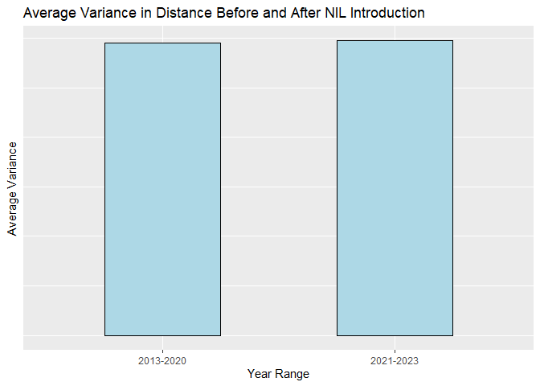

```r
nil_difference = schools_dist_var %>%
  mutate(nil = ifelse(Year >= 2021, "2021-2023", "2013-2020")) %>%
  group_by(nil) %>%
  summarize(avg_var = mean(distance_var))

ggplot(nil_difference, aes(x=nil, y=avg_var)) +
  geom_col(width=0.5, color="black", fill="lightblue") +
  theme(axis.text.y = element_blank(), axis.ticks.y = element_blank()) +
  ylab("Average Variance") +
  xlab("Year Range") +
  ggtitle("Average Variance in Distance Before and After NIL Introduction")
```

We can see a slight increase in variance, but it is likely negligible, so this will probably need a few more years of data to see changes, if any. However, we can still look at this by school.

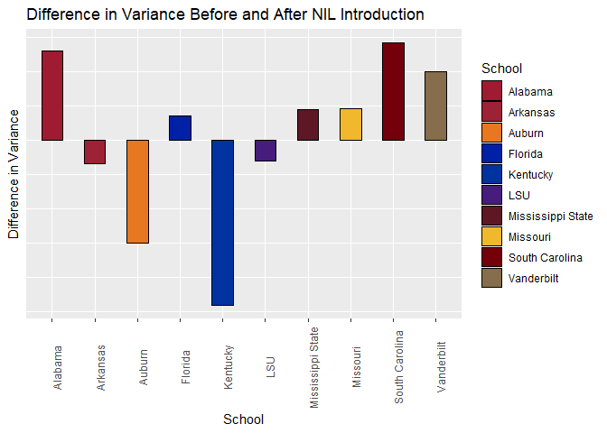

```r
nil_diff_school = schools_dist_var %>%
  mutate(nil = ifelse(Year >= 2021, "after", "before")) %>%
  group_by(nil, School) %>%
  summarize(avg_var = mean(distance_var)) %>%
  pivot_wider(names_from=nil, values_from=avg_var) %>%
  mutate(var_diff = after-before)

ggplot(nil_diff_school, aes(x=School, y=var_diff, fill=School)) +
  geom_col(width=0.5, color="black") +
  theme(axis.text.y = element_blank(), axis.ticks.y = element_blank(), axis.text.x = element_text(angle=90, vjust=1)) +
  scale_fill_manual(values=group.colors) +
  ylab("Difference in Variance") +
  xlab("School") +
  ggtitle("Difference in Variance Before and After NIL Introduction")
```

We see from this that 6 out of 10 schools have increased their recruitment range since NIL was introduced. Some like Kentucky and Auburn have adjusted to bring recruits in that are closer to campus.

### In State Recruiting

Which schools (out of the subset that I have scraped) are the best at recruiting in their state? Out of all of the cities in their state, how many are they the majority recruiter in?

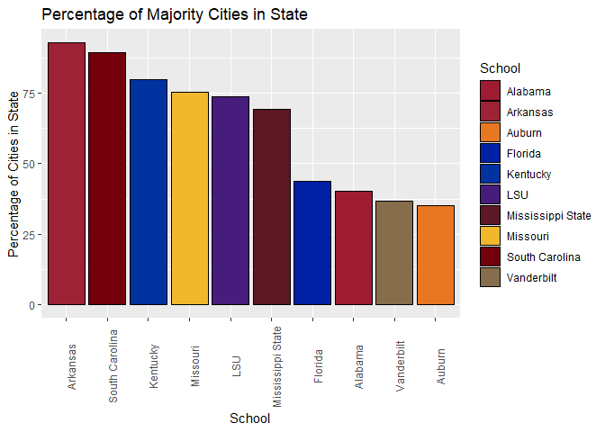

```r
unis = sort(unique(cities$School))
uni_states = data.frame(School = unis, State = c("Alabama", "Arkansas", "Alabama", "Florida", "Kentucky", "Louisiana", "Mississippi", "Missouri", "South Carolina", "Tennessee"))

# Give the cities dataframe all of their states
hometowns_unique = distinct(hometowns) %>% arrange(City)

cities$State = hometowns_unique$State
cities_filtered = cities %>% filter(State %in% uni_states$State)


# SQL query to determine percentage of cities in state that a school has a majority in
sql_calc = sqldf("with cte as (SELECT State, School, COUNT(Hometown) as Num_Cities,
                 count(*) * 100.0 / sum(count(*)) over(PARTITION BY State) as Percentage_Of_Cities
                 FROM cities_filtered
                 GROUP BY State, School)
                 SELECT * FROM cte WHERE State == School OR (State = 'Alabama' AND School = 'Auburn') OR (State = 'Louisiana' AND School = 'LSU') OR (State = 'Tennessee' AND School = 'Vanderbilt') OR (State = 'Mississippi' AND School = 'Mississippi State')")


# Plot
ggplot(sql_calc, aes(x=reorder(School, -Percentage_Of_Cities), y=Percentage_Of_Cities, fill=School)) +
  geom_col(color="black") +
  theme(axis.text.x=element_text(angle=90, vjust=1)) +
  scale_fill_manual(values=group.colors) +
  xlab("School") +
  ylab("Percentage of Cities in State") +
  ggtitle("Percentage of Majority Cities in State")
```

## Thank You!

Thanks for listening to my presentation! This took a lot of hard work over the last week or so, so I appreciate the support.